# Kevin’s R Assignment

Kevin Falk

October 16, 2017

## This is my Markdown document.

Load libraries

```r
library(plyr)
library(dplyr)
```

```r
library(ggplot2)
library(reshape2)
```

Set working directory

```r
setwd("/Users/falk/BCB546X/BCB546X-Fall2017/R_Assignment")
```

Part 1

read in fang_genotypes text file and set it as genotypes

```r
genotypes <- read.table("fang_et_al_genotypes.txt", header = T, stringsAsFactors = T)
```

Take a look at the data

```r
head(genotypes)
```

```
##   Sample_ID   JG_OTU Group abph1.20 abph1.22 ae1.3 ae1.4 ae1.5 an1.4 ba1.6
## 1     SL-15 T-aust-1 TRIPS      ?/?      ?/?   T/T   G/G   T/T   C/C   ?/?
## 2     SL-16 T-aust-2 TRIPS      ?/?      ?/?   T/T   ?/?   T/T   C/C   A/G
## 3     SL-11 T-brav-1 TRIPS      ?/?      ?/?   T/T   G/G   T/T   ?/?   G/G
## 4     SL-12 T-brav-2 TRIPS      ?/?      ?/?   T/T   G/G   T/T   C/C   G/G
## 5     SL-18   T-cund TRIPS      ?/?      ?/?   T/T   G/G   T/T   C/C   ?/?
## 6      SL-2 T-dact-1 TRIPS      ?/?      ?/?   T/T   G/G   T/T   C/C   A/G
##   ba1.9 bt2.5 bt2.7 bt2.8 Fea2.1 Fea2.5 id1.3 lg2.11 lg2.2 pbf1.1 pbf1.2
## 1   G/G   ?/?   A/A   ?/?    C/C    A/A   T/T    C/C   A/A    ?/?    ?/?
## 2   G/G   ?/?   A/A   ?/?    C/C    A/A   T/T    C/C   A/A    T/T    ?/?
## 3   G/G   C/C   A/A   ?/?    ?/?    A/A   T/T    C/C   A/A    T/T    ?/?
## 4   G/G   C/C   A/A   ?/?    ?/?    A/A   T/T    C/C   A/A    T/T    ?/?
## 5   G/G   ?/?   A/A   ?/?    C/C    A/A   T/T    C/C   A/A    T/T    ?/?
## 6   G/G   ?/?   A/A   ?/?    C/C    A/A   T/T    C/C   A/A    T/T    ?/?
##   pbf1.3 pbf1.5 pbf1.6 pbf1.7 pbf1.8 PZA00003.11 PZA00004.2 PZA00005.8
```

[output cut: 1119 more lines]

```r
str(genotypes)
```

```
## 'data.frame':    2782 obs. of  986 variables:
##  $ Sample_ID     : Factor w/ 2782 levels "BKN_001","BKN_002",..: 445 446 442 443 448 450 457 459 460 458 ...
##  $ JG_OTU        : Factor w/ 2782 levels "T-aust-1","T-aust-2",..: 1 2 3 4 5 6 7 8 9 10 ...
##  $ Group         : Factor w/ 16 levels "TRIPS","ZDIPL",..: 1 1 1 1 1 1 1 1 1 1 ...
##  $ abph1.20      : Factor w/ 4 levels "?/?","C/C","C/G",..: 1 1 1 1 1 1 1 1 1 1 ...
##  $ abph1.22      : Factor w/ 4 levels "?/?","A/A","A/C",..: 1 1 1 1 1 1 1 1 1 1 ...
##  $ ae1.3         : Factor w/ 4 levels "?/?","G/G","G/T",..: 4 4 4 4 4 4 4 4 4 4 ...
##  $ ae1.4         : Factor w/ 4 levels "?/?","A/A","A/G",..: 4 1 4 4 4 4 4 4 4 4 ...
##  $ ae1.5         : Factor w/ 4 levels "?/?","C/C","C/T",..: 4 4 4 4 4 4 4 4 4 4 ...
##  $ an1.4         : Factor w/ 4 levels "?/?","C/C","C/G",..: 2 2 1 2 2 2 2 2 2 2 ...
##  $ ba1.6         : Factor w/ 4 levels "?/?","A/A","A/G",..: 1 3 4 4 1 3 4 1 4 1 ...
##  $ ba1.9         : Factor w/ 4 levels "?/?","G/G","G/T",..: 2 2 2 2 2 2 2 2 2 2 ...
##  $ bt2.5         : Factor w/ 4 levels "?/?","C/C","C/T",..: 1 1 2 2 1 1 1 1 1 1 ...
##  $ bt2.7         : Factor w/ 4 levels "?/?","A/A","A/G",..: 2 2 2 2 2 2 2 2 2 2 ...
##  $ bt2.8         : Factor w/ 4 levels "?/?","A/A","A/G",..: 1 1 1 1 1 1 1 1 1 1 ...
```

[output cut: 86 more lines]

```r
nrow(genotypes)
```

```
## [1] 2782
```

```r
ncol(genotypes)
```

```
## [1] 986
```

```r
geno_table <- tbl_df(genotypes)
head(geno_table)
```

```
## # A tibble: 6 x 986
##   Sample_ID   JG_OTU  Group abph1.20 abph1.22  ae1.3  ae1.4  ae1.5  an1.4
##      <fctr>   <fctr> <fctr>   <fctr>   <fctr> <fctr> <fctr> <fctr> <fctr>
## 1     SL-15 T-aust-1  TRIPS      ?/?      ?/?    T/T    G/G    T/T    C/C
## 2     SL-16 T-aust-2  TRIPS      ?/?      ?/?    T/T    ?/?    T/T    C/C
## 3     SL-11 T-brav-1  TRIPS      ?/?      ?/?    T/T    G/G    T/T    ?/?
## 4     SL-12 T-brav-2  TRIPS      ?/?      ?/?    T/T    G/G    T/T    C/C
## 5     SL-18   T-cund  TRIPS      ?/?      ?/?    T/T    G/G    T/T    C/C
## 6      SL-2 T-dact-1  TRIPS      ?/?      ?/?    T/T    G/G    T/T    C/C
## # ... with 977 more variables: ba1.6 <fctr>, ba1.9 <fctr>, bt2.5 <fctr>,
## #   bt2.7 <fctr>, bt2.8 <fctr>, Fea2.1 <fctr>, Fea2.5 <fctr>,
## #   id1.3 <fctr>, lg2.11 <fctr>, lg2.2 <fctr>, pbf1.1 <fctr>,
## #   pbf1.2 <fctr>, pbf1.3 <fctr>, pbf1.5 <fctr>, pbf1.6 <fctr>,
## #   pbf1.7 <fctr>, pbf1.8 <fctr>, PZA00003.11 <fctr>, PZA00004.2 <fctr>,
## #   PZA00005.8 <fctr>, PZA00005.9 <fctr>, PZA00006.13 <fctr>,
## #   PZA00006.14 <fctr>, PZA00008.1 <fctr>, PZA00010.5 <fctr>,
## #   PZA00013.10 <fctr>, PZA00013.11 <fctr>, PZA00013.9 <fctr>,
## #   PZA00015.4 <fctr>, PZA00017.1 <fctr>, PZA00018.5 <fctr>,
## #   PZA00029.11 <fctr>, PZA00029.12 <fctr>, PZA00030.11 <fctr>,
## #   PZA00031.5 <fctr>, PZA00041.3 <fctr>, PZA00042.2 <fctr>,
## #   PZA00042.5 <fctr>, PZA00043.7 <fctr>, PZA00045.1 <fctr>,
## #   PZA00047.2 <fctr>, PZA00049.12 <fctr>, PZA00050.9 <fctr>,
## #   PZA00051.2 <fctr>, PZA00058.5 <fctr>, PZA00058.6 <fctr>,
## #   PZA00060.2 <fctr>, PZA00061.1 <fctr>, PZA00065.2 <fctr>,
## #   PZA00069.4 <fctr>, PZA00070.5 <fctr>, PZA00078.2 <fctr>,
## #   PZA00079.1 <fctr>, PZA00081.17 <fctr>, PZA00084.2 <fctr>,
## #   PZA00084.3 <fctr>, PZA00086.8 <fctr>, PZA00088.3 <fctr>,
## #   PZA00090.2 <fctr>, PZA00092.1 <fctr>, PZA00092.5 <fctr>,
## #   PZA00093.2 <fctr>, PZA00096.26 <fctr>, PZA00097.13 <fctr>,
## #   PZA00098.14 <fctr>, PZA00100.10 <fctr>, PZA00100.12 <fctr>,
## #   PZA00100.14 <fctr>, PZA00100.9 <fctr>, PZA00103.20 <fctr>,
## #   PZA00106.9 <fctr>, PZA00107.18 <fctr>, PZA00108.12 <fctr>,
## #   PZA00108.14 <fctr>, PZA00108.15 <fctr>, PZA00109.3 <fctr>,
## #   PZA00109.5 <fctr>, PZA00111.2 <fctr>, PZA00111.4 <fctr>,
## #   PZA00111.5 <fctr>, PZA00111.6 <fctr>, PZA00111.8 <fctr>,
## #   PZA00114.3 <fctr>, PZA00116.2 <fctr>, PZA00119.4 <fctr>,
## #   PZA00120.4 <fctr>, PZA00123.1 <fctr>, PZA00125.2 <fctr>,
## #   PZA00131.14 <fctr>, PZA00132.17 <fctr>, PZA00132.18 <fctr>,
## #   PZA00132.3 <fctr>, PZA00135.6 <fctr>, PZA00137.2 <fctr>,
## #   PZA00139.14 <fctr>, PZA00140.10 <fctr>, PZA00140.6 <fctr>,
## #   PZA00140.9 <fctr>, PZA00142.6 <fctr>, PZA00148.2 <fctr>, ...
```

```r
glimpse(geno_table)
```

```
## Observations: 2,782
## Variables: 986
## $ Sample_ID      <fctr> SL-15, SL-16, SL-11, SL-12, SL-18, SL-2, SL-4,...
## $ JG_OTU         <fctr> T-aust-1, T-aust-2, T-brav-1, T-brav-2, T-cund...
## $ Group          <fctr> TRIPS, TRIPS, TRIPS, TRIPS, TRIPS, TRIPS, TRIP...
## $ abph1.20       <fctr> ?/?, ?/?, ?/?, ?/?, ?/?, ?/?, ?/?, ?/?, ?/?, ?...
## $ abph1.22       <fctr> ?/?, ?/?, ?/?, ?/?, ?/?, ?/?, ?/?, ?/?, ?/?, ?...
## $ ae1.3          <fctr> T/T, T/T, T/T, T/T, T/T, T/T, T/T, T/T, T/T, T...
## $ ae1.4          <fctr> G/G, ?/?, G/G, G/G, G/G, G/G, G/G, G/G, G/G, G...
## $ ae1.5          <fctr> T/T, T/T, T/T, T/T, T/T, T/T, T/T, T/T, T/T, T...
## $ an1.4          <fctr> C/C, C/C, ?/?, C/C, C/C, C/C, C/C, C/C, C/C, C...
## $ ba1.6          <fctr> ?/?, A/G, G/G, G/G, ?/?, A/G, G/G, ?/?, G/G, ?...
## $ ba1.9          <fctr> G/G, G/G, G/G, G/G, G/G, G/G, G/G, G/G, G/G, G...
## $ bt2.5          <fctr> ?/?, ?/?, C/C, C/C, ?/?, ?/?, ?/?, ?/?, ?/?, ?...
## $ bt2.7          <fctr> A/A, A/A, A/A, A/A, A/A, A/A, A/A, A/A, A/A, A...
```

[output cut: 973 more lines]

```r
data.frame(head(geno_table))
```

```
##   Sample_ID   JG_OTU Group abph1.20 abph1.22 ae1.3 ae1.4 ae1.5 an1.4 ba1.6
## 1     SL-15 T-aust-1 TRIPS      ?/?      ?/?   T/T   G/G   T/T   C/C   ?/?
## 2     SL-16 T-aust-2 TRIPS      ?/?      ?/?   T/T   ?/?   T/T   C/C   A/G
## 3     SL-11 T-brav-1 TRIPS      ?/?      ?/?   T/T   G/G   T/T   ?/?   G/G
## 4     SL-12 T-brav-2 TRIPS      ?/?      ?/?   T/T   G/G   T/T   C/C   G/G
## 5     SL-18   T-cund TRIPS      ?/?      ?/?   T/T   G/G   T/T   C/C   ?/?
## 6      SL-2 T-dact-1 TRIPS      ?/?      ?/?   T/T   G/G   T/T   C/C   A/G
##   ba1.9 bt2.5 bt2.7 bt2.8 Fea2.1 Fea2.5 id1.3 lg2.11 lg2.2 pbf1.1 pbf1.2
## 1   G/G   ?/?   A/A   ?/?    C/C    A/A   T/T    C/C   A/A    ?/?    ?/?
## 2   G/G   ?/?   A/A   ?/?    C/C    A/A   T/T    C/C   A/A    T/T    ?/?
## 3   G/G   C/C   A/A   ?/?    ?/?    A/A   T/T    C/C   A/A    T/T    ?/?
## 4   G/G   C/C   A/A   ?/?    ?/?    A/A   T/T    C/C   A/A    T/T    ?/?
## 5   G/G   ?/?   A/A   ?/?    C/C    A/A   T/T    C/C   A/A    T/T    ?/?
## 6   G/G   ?/?   A/A   ?/?    C/C    A/A   T/T    C/C   A/A    T/T    ?/?
##   pbf1.3 pbf1.5 pbf1.6 pbf1.7 pbf1.8 PZA00003.11 PZA00004.2 PZA00005.8
```

[output cut: 1119 more lines]

Read in snp_position text file and set it as snps

```r
snps <- read.delim("snp_position.txt", header = T, stringsAsFactors = F)
```

Take a look at the data

```r
head(snps)
```

```
##     SNP_ID cdv_marker_id Chromosome  Position alt_pos mult_positions
## 1 abph1.20          5976          2  27403404
## 2 abph1.22          5978          2  27403892
## 3    ae1.3          6605          5 167889790
## 4    ae1.4          6606          5 167889682
## 5    ae1.5          6607          5 167889821
## 6    an1.4          5982          1 240498509
##   amplicon cdv_map_feature.name  gene candidate.random Genaissance_daa_id
## 1    abph1             AB042260 abph1        candidate               8393
## 2    abph1             AB042260 abph1        candidate               8394
## 3      ae1                  ae1   ae1        candidate               8395
## 4      ae1                  ae1   ae1        candidate               8396
## 5      ae1                  ae1   ae1        candidate               8397
## 6      an1                  an1   an1        candidate               8398
##   Sequenom_daa_id count_amplicons count_cmf count_gene
## 1           10474               1         1          1
## 2           10475               0         0          0
## 3           10477               1         1          1
## 4           10478               0         0          0
## 5           10479               0         0          0
## 6           10481               1         1          1
```

```r
str(genotypes)
```

```
## 'data.frame':    2782 obs. of  986 variables:
##  $ Sample_ID     : Factor w/ 2782 levels "BKN_001","BKN_002",..: 445 446 442 443 448 450 457 459 460 458 ...
##  $ JG_OTU        : Factor w/ 2782 levels "T-aust-1","T-aust-2",..: 1 2 3 4 5 6 7 8 9 10 ...
##  $ Group         : Factor w/ 16 levels "TRIPS","ZDIPL",..: 1 1 1 1 1 1 1 1 1 1 ...
##  $ abph1.20      : Factor w/ 4 levels "?/?","C/C","C/G",..: 1 1 1 1 1 1 1 1 1 1 ...
##  $ abph1.22      : Factor w/ 4 levels "?/?","A/A","A/C",..: 1 1 1 1 1 1 1 1 1 1 ...
##  $ ae1.3         : Factor w/ 4 levels "?/?","G/G","G/T",..: 4 4 4 4 4 4 4 4 4 4 ...
##  $ ae1.4         : Factor w/ 4 levels "?/?","A/A","A/G",..: 4 1 4 4 4 4 4 4 4 4 ...
##  $ ae1.5         : Factor w/ 4 levels "?/?","C/C","C/T",..: 4 4 4 4 4 4 4 4 4 4 ...
##  $ an1.4         : Factor w/ 4 levels "?/?","C/C","C/G",..: 2 2 1 2 2 2 2 2 2 2 ...
##  $ ba1.6         : Factor w/ 4 levels "?/?","A/A","A/G",..: 1 3 4 4 1 3 4 1 4 1 ...
##  $ ba1.9         : Factor w/ 4 levels "?/?","G/G","G/T",..: 2 2 2 2 2 2 2 2 2 2 ...
##  $ bt2.5         : Factor w/ 4 levels "?/?","C/C","C/T",..: 1 1 2 2 1 1 1 1 1 1 ...
##  $ bt2.7         : Factor w/ 4 levels "?/?","A/A","A/G",..: 2 2 2 2 2 2 2 2 2 2 ...
##  $ bt2.8         : Factor w/ 4 levels "?/?","A/A","A/G",..: 1 1 1 1 1 1 1 1 1 1 ...
```

[output cut: 86 more lines]

```r
nrow(snps)
```

```
## [1] 983
```

```r
ncol(snps)
```

```
## [1] 15
```

```r
snps_table <- tbl_df(snps)
head(snps_table)
```

```
## # A tibble: 6 x 15
##     SNP_ID cdv_marker_id Chromosome  Position alt_pos mult_positions
##      <chr>         <int>      <chr>     <chr>   <chr>          <chr>
## 1 abph1.20          5976          2  27403404
## 2 abph1.22          5978          2  27403892
## 3    ae1.3          6605          5 167889790
## 4    ae1.4          6606          5 167889682
## 5    ae1.5          6607          5 167889821
## 6    an1.4          5982          1 240498509
## # ... with 9 more variables: amplicon <chr>, cdv_map_feature.name <chr>,
## #   gene <chr>, candidate.random <chr>, Genaissance_daa_id <int>,
## #   Sequenom_daa_id <int>, count_amplicons <int>, count_cmf <int>,
## #   count_gene <int>
```

```r
glimpse(snps_table)
```

```
## Observations: 983
## Variables: 15
## $ SNP_ID               <chr> "abph1.20", "abph1.22", "ae1.3", "ae1.4",...
## $ cdv_marker_id        <int> 5976, 5978, 6605, 6606, 6607, 5982, 3463,...
## $ Chromosome           <chr> "2", "2", "5", "5", "5", "1", "3", "3", "...
## $ Position             <chr> "27403404", "27403892", "167889790", "167...
## $ alt_pos              <chr> "", "", "", "", "", "", "", "", "", "", "...
## $ mult_positions       <chr> "", "", "", "", "", "", "", "", "", "", "...
## $ amplicon             <chr> "abph1", "abph1", "ae1", "ae1", "ae1", "a...
## $ cdv_map_feature.name <chr> "AB042260", "AB042260", "ae1", "ae1", "ae...
## $ gene                 <chr> "abph1", "abph1", "ae1", "ae1", "ae1", "a...
## $ candidate.random     <chr> "candidate", "candidate", "candidate", "c...
## $ Genaissance_daa_id   <int> 8393, 8394, 8395, 8396, 8397, 8398, 8399,...
## $ Sequenom_daa_id      <int> 10474, 10475, 10477, 10478, 10479, 10481,...
## $ count_amplicons      <int> 1, 0, 1, 0, 0, 1, 1, 0, 1, 0, 0, 1, 0, 1,...
## $ count_cmf            <int> 1, 0, 1, 0, 0, 1, 0, 0, 1, 0, 0, 1, 0, 1,...
## $ count_gene           <int> 1, 0, 1, 0, 0, 1, 1, 0, 1, 0, 0, 1, 0, 1,...
```

Create a list of the SNP Names for later use

```r
SNP_names <- colnames(genotypes)[-c(1:3)]
```

MAIZE

Use the filter verb to screen for just the maize SNPs

```r
maize <- filter(genotypes, Group %in% c("ZMMIL","ZMMLR","ZMMMR"))
```

Lets take a look at our new df

```r
nrow(maize)
```

```
## [1] 1573
```

```r
head(maize)
```

```
##   Sample_ID                 JG_OTU Group abph1.20 abph1.22 ae1.3 ae1.4
## 1 ZDP_0752a Zmm-LR-ACOM-usa-NM-1_s ZMMLR      C/G      A/A   T/T   G/G
## 2 ZDP_0793a   Zmm-LR-ACOM-usa-NM-2 ZMMLR      C/G      A/A   T/T   G/G
## 3 ZDP_0612a   Zmm-LR-ALAZ-Per-JEQU ZMMLR      C/C      A/A   T/T   G/G
## 4 ZDP_0602a   Zmm-LR-ALAZ-Per-MOCH ZMMLR      C/G      A/A   G/T   A/G
## 5 ZDP_0581a   Zmm-LR-ALAZ-Per-PICS ZMMLR      C/C      A/A   T/T   G/G
## 6 ZDP_0552a   Zmm-LR-ALAZ-Per-VIRU ZMMLR      C/G      A/A   T/T   G/G
##   ae1.5 an1.4 ba1.6 ba1.9 bt2.5 bt2.7 bt2.8 Fea2.1 Fea2.5 id1.3 lg2.11
## 1   C/C   C/G   G/G   G/G   C/C   ?/?   A/A    C/G    A/A   C/T    C/C
## 2   C/T   C/G   A/G   G/T   C/C   ?/?   A/A    C/G    A/A   C/T    C/C
## 3   C/C   C/C   G/G   ?/?   C/C   G/G   A/A    C/G    A/G   C/C    C/C
## 4   C/T   C/C   G/G   G/G   C/C   G/G   A/A    C/G    A/G   C/C    C/C
## 5   C/T   C/C   G/G   G/G   C/C   G/G   A/A    C/C    G/G   C/T    C/C
## 6   C/T   C/C   G/G   G/G   C/C   G/G   A/A    C/G    A/G   C/C    C/T
##   lg2.2 pbf1.1 pbf1.2 pbf1.3 pbf1.5 pbf1.6 pbf1.7 pbf1.8 PZA00003.11
```

[output cut: 1119 more lines]

Transpose maize df so that it reads horizontally

```r
maize_t <- t(maize)
```

Use merge function to combine both files together using the SNP_ID column in the snps_table and the dataframe’s actual row names in the maize_t df.

```r
maize_m <- merge(snps_table, maize_t, by.x = "SNP_ID", by.y = "row.names")
```

Cut out unwanted columns

```r
maize_c <- maize_m[,-c(2,5:15)]
```

Change the ? to - using the apply function

```r
df <- apply(maize_c,2, function(x) gsub("\\?/\\?", "-/-", x))
```

Apply outputs a matrix, so change it to a dataframe

```r
genotypes2 <- as.data.frame(df)
```

Reorder dataframe by increasing position number

```r
maize_increasing_snps <- maize_c[order(as.numeric(as.character(maize_c$Position))),]
```

Reorder dataframe by decreasing position number

```r
maize_decreasing_snps <- genotypes2[order(-as.numeric(as.character(genotypes2$Position))),]
```

Instead of manually creating each dataframe, we can use a for loop

```r
for (i in 1:10) {
  x <- maize_increasing_snps[maize_increasing_snps$Chromosome == i,]
#We can create a new CSV file for each chromosome
write.csv(x, sprintf("maize_increasing_snps_chromosome_%d.csv", i), row.names = F)
}
```

Instead of manually creating each dataframe, we can use a for loop

```r
for (i in 1:10) {
  x <- maize_decreasing_snps[maize_decreasing_snps$Chromosome == i,]
#We can create a new CSV file for each chromosome
  write.csv(x, sprintf("maize_decreasing_snps_chromosome_%d.csv", i), row.names = F)
}
```

TEOSINTE

Use the filter verb to screen for just the teosinte SNPs

```r
teosinte <- filter(genotypes, Group %in% c("ZMPBA","ZMPIL","ZMPJA"))
```

lets take a look at our new df

```r
head(teosinte)
```

```
##   Sample_ID             JG_OTU Group abph1.20 abph1.22 ae1.3 ae1.4 ae1.5
## 1     S0881 Zmp-B-ACAPET-GR-01 ZMPBA      C/G      A/A   T/T   G/G   T/T
## 2     S1057 Zmp-B-ACAPET-GR-02 ZMPBA      C/G      A/A   G/T   A/G   T/T
## 3     S1087 Zmp-B-ACAPET-GR-03 ZMPBA      G/G      A/A   T/T   G/G   T/T
## 4     S1689 Zmp-B-ACAPET-GR-04 ZMPBA      G/G      A/A   T/T   G/G   T/T
## 5     S1697 Zmp-B-ACAPET-GR-05 ZMPBA      C/G      A/A   T/T   G/G   T/T
## 6     S1698 Zmp-B-ACAPET-GR-06 ZMPBA      C/G      A/A   T/T   A/G   T/T
##   an1.4 ba1.6 ba1.9 bt2.5 bt2.7 bt2.8 Fea2.1 Fea2.5 id1.3 lg2.11 lg2.2
## 1   C/C   A/G   G/G   T/T   A/A   G/G    G/G    A/A   C/C    C/C   A/G
## 2   C/C   A/A   G/G   C/T   A/A   ?/?    C/G    A/G   C/C    C/C   A/A
## 3   C/C   A/A   G/G   C/T   A/A   A/G    C/C    A/G   T/T    C/C   A/A
## 4   C/C   A/A   G/G   C/C   A/A   A/A    ?/?    A/A   C/T    C/C   A/A
## 5   C/C   A/A   G/G   C/C   A/A   A/A    C/G    A/G   C/C    C/C   A/G
## 6   C/C   A/A   G/G   C/T   A/A   A/G    G/G    A/A   C/C    C/C   A/A
##   pbf1.1 pbf1.2 pbf1.3 pbf1.5 pbf1.6 pbf1.7 pbf1.8 PZA00003.11 PZA00004.2
```

[output cut: 1119 more lines]

```r
nrow(teosinte)
```

```
## [1] 975
```

```r
ncol(teosinte)
```

```
## [1] 986
```

Transpose teosinte df so that it reads horizontally

```r
teosinte_t <- t(teosinte)
```

Use merge function to combine both files together using the SNP_ID column in the snps_table and the dataframe’s actual row names in the teosinte_t df.

```r
teosinte_m <- merge(snps_table, teosinte_t, by.x = "SNP_ID", by.y = "row.names")
```

Cut out unwanted columns

```r
teosinte_c <- teosinte_m[,-c(2,5:15)]
```

Change the ? to - using the apply function

```r
df <- apply(teosinte_c,2, function(x) gsub("\\?/\\?", "-/-", x))
```

Apply outputs a matrix, so change it to a dataframe

```r
genotypes2 <- as.data.frame(df)
```

Reorder dataframe by increasing position number

```r
teosinte_increasing_snps <- teosinte_c[order(as.numeric(as.character(teosinte_c$Position))),]
```

Reorder dataframe by decreasing position number

```r
teosinte_decreasing_snps <- genotypes2[order(-as.numeric(as.character(genotypes2$Position))),]
```

Instead of manually creating each dataframe, we can use a for loop

```r
for (i in 1:10) {
  x <- teosinte_increasing_snps[teosinte_increasing_snps$Chromosome == i,]
  #we can create a new CSV file for each chromosome
  write.csv(x, sprintf("teosinte_increasing_snps_chromosome_%d.csv", i), row.names = F)
}
```

Instead of manually creating each dataframe, we can use a for loop

```r
for (i in 1:10) {
  x <- teosinte_decreasing_snps[teosinte_decreasing_snps$Chromosome == i,]
  #we can create a new CSV file for each chromosome
  write.csv(x, sprintf("teosinte_decreasing_snps_chromosome_%d.csv", i), row.names = F)
}
```

Part 2

Transpose genotypes df so that it reads horizontally

```r
genotypes_t <- t(genotypes)
```

```r
genotypes_m <- merge(snps, genotypes_t, by.x = "SNP_ID", by.y = "row.names", all.y = TRUE)
```

Pull the name of all the SNPs from the original file

```r
SNP_names <- colnames(genotypes)[-c(1:3)]
```

Reshape the data using the melt command

```r
alleles <- melt(genotypes, measure.vars = SNP_names)
```

Look at the just the OTU and Groups and SNPs

```r
genotypes_n <- genotypes_m[,-c(1:15)]
```

Make the OTU Groups the header

```r
colnames(genotypes_n) <- as.character(unlist(genotypes_n[14,]))
```

Remove the OTU and Groups rows

```r
genotypes_n <- genotypes_n[-c(14,16),]
View(genotypes_n)
```

Look at the just the other stuff

```r
genotypes_o <- genotypes_m[,c(1:15)]
```

Remove the rows of OTU and Groups

```r
genotypes_o <- genotypes_o[-c(14,16),]
```

Bind both dataframes together in new format

```r
genotypes_p <- cbind(genotypes_o, genotypes_n)
genotypes.p <- melt(genotypes_p)
```

[output not shown]

```r
genotypes_s <- genotypes_m[order(as.numeric(as.character(genotypes_m$Chromosome))),]
genotypes_s <- tbl_df(genotypes_s)
```

Plot the SNPs per chromosome

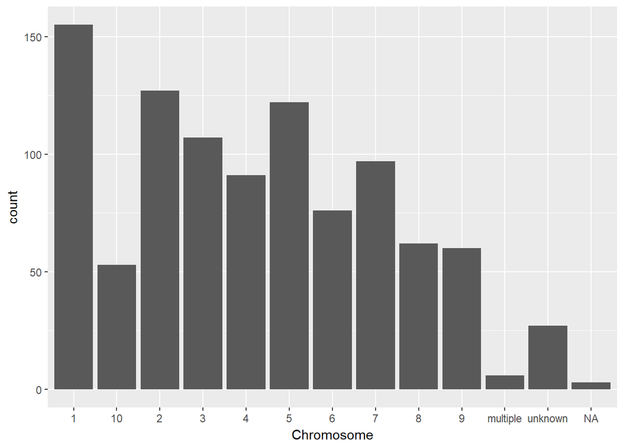

```r
ggplot(genotypes_s, aes(x=Chromosome)) + geom_bar()
```

Create a summary table of SNPs per chromosome

```r
x <- genotypes_s %>% group_by(Chromosome) %>% summarise(SNP_count = n())
```

Turn columns into factors so that we can plot them

```r
x$Chromosome <- as.factor(x$Chromosome)
x$SNP_count <- as.factor(x$SNP_count)
```

Plot the SNPs per chromosome

[figure not shown]

```r
plot(x$Chromosome, x$SNP_count, xlab = "Chromosome", ylab = "SNP Count")
```

In general, there is a decreasing number of SNPs from the first to tenth chromosome ###################################################################################### Missing data and amount of heterozygosity Create a new column to indicate whether a particular site is homozygous

```r
alleles <- apply(alleles,2, function(x) gsub("C/C", TRUE, x))
alleles <- apply(alleles,2, function(x) gsub("T/T", TRUE, x))
alleles <- apply(alleles,2, function(x) gsub("A/A", TRUE, x))
alleles <- apply(alleles,2, function(x) gsub("G/G", TRUE, x))
alleles <- apply(alleles,2, function(x) gsub("G/T", FALSE, x))
alleles <- apply(alleles,2, function(x) gsub("A/C", FALSE, x))
alleles <- apply(alleles,2, function(x) gsub("A/G", FALSE, x))
alleles <- apply(alleles,2, function(x) gsub("A/T", FALSE, x))
alleles <- apply(alleles,2, function(x) gsub("C/G", FALSE, x))
alleles <- apply(alleles,2, function(x) gsub("C/T", FALSE, x))
alleles <- apply(alleles,2, function(x) gsub("C/A", FALSE, x))
alleles <- apply(alleles,2, function(x) gsub("G/A", FALSE, x))
alleles <- apply(alleles,2, function(x) gsub("G/C", FALSE, x))
alleles <- apply(alleles,2, function(x) gsub("T/A", FALSE, x))
alleles <- apply(alleles,2, function(x) gsub("T/C", FALSE, x))
alleles <- apply(alleles,2, function(x) gsub("T/G", FALSE, x))
#Recode the missing data as NA
alleles <- apply(alleles,2, function(x) gsub("\\?/\\?", NA, x))
```

Name columns in the data set

```r
colnames(alleles)[1:5] <- c("Sample_ID","JG_OTU","Group","SNP_ID","Homozygous")
alleles_df <- as.data.frame(alleles)
```

Sort your dataframe using Group and Species_ID values

```r
alleles_s <-arrange(alleles_df, Sample_ID, Group)
```

Count the number of Homozygous (TRUE) and Heterozygous (FALSE)

```r
alleles_tf <- alleles_s %>%
  group_by(Homozygous) %>%
  tally(sort=TRUE)
```

Use ggplot to plot the number of Homozygous, Non-homozygous and NA samples

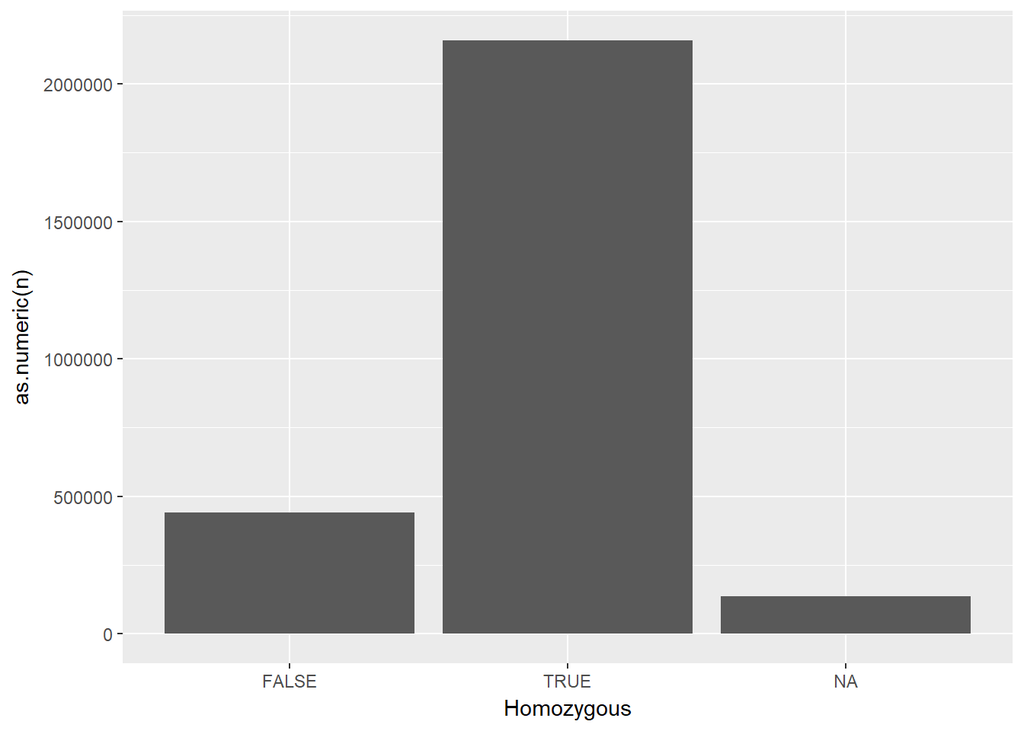

```r
ggplot(data = alleles_tf, aes(x = Homozygous, y = as.numeric(n))) + geom_bar(stat = "identity", position = "stack")
```

Create dataframe that compares Group with Homozygousity

```r
group_homo <- alleles_s %>%
  group_by(Group) %>%
  select(Homozygous) %>%
  data.frame()
```

Visualize one other feature of the dataset. Histogram comparing homozygous loci and species grouping

[figure not shown]

```r
ggplot(data = group_homo, aes(x = Group, y = Homozygous))+ geom_bar(stat = "identity", position = "stack")
```